# Table of Contents

## 条件付き期待値の計算

簡単な線形モデル \begin{eqnarray} y = x + v\ x～N(\overline{x},\sigma^2_a)\ v～N(0,\sigma^2_v) \end{eqnarray}

### 正規分布の加法性

\begin{eqnarray} a ～ N(\mu_a, \sigma_a^2)\\ b ～ N(\mu_b, \sigma_b^2)\\ であるとき\\ a + b も正規分布に従い、\\ a + b ～ N(\mu_a+\mu_b, \sigma_a^2+\sigma_b^2) となる。 \end{eqnarray}

### [数値例] x

```python
import numpy as np
np.random.seed(0)
N = 1000
```

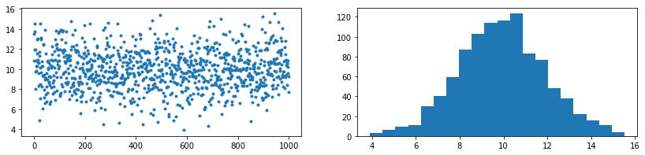

```python
#
x_ave = 10
x_dev = 2
x_var = x_dev**2
x = np.random.normal(x_ave, x_dev, N)

#
import matplotlib.pyplot as plt
plt.figure(figsize=(14, 3))
plt.subplot(1, 2, 1)
plt.plot(x, '.')
plt.subplot(1, 2, 2)
plt.hist(x, bins=20)
plt.show()
```

### [数値例] y

```python
v_ave = 0
v_dev = 2
v_var = v_dev**2
v = np.random.normal(v_ave, v_dev, N)
y = x + v

print(np.mean(y))
print(np.cov(y))
print(np.sqrt(np.cov(y)))
```

```
9.87138004544
8.202386950839964
2.86398096202
```

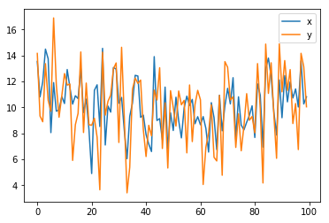

```python
import matplotlib.pyplot as plt
plt.plot(x[:100],label='x')
plt.plot(y[:100],label='y')
plt.legend()
plt.show()
```

### 事後確率密度と条件付き期待値

#### ベイズの定理

\begin{eqnarray} p(x_i \mid y_i) &=& \frac {集合「x=xi」における、y=yiとなる事象} {集合「全x」における、y=yiとなる事象全て} \\&=& \frac {p(y_i \mid x_i)p(x_i)} {\int p(y_i \mid x)p(x)dx} \end{eqnarray}

[output not shown]

ここで \begin{eqnarray} \frac{1}{\tau^2} = \frac{1}{\sigma_a^2} + \frac{1}{\sigma_v^2} \ \alpha = \frac{\overline{x}}{\sigma_a^2} + \frac{y}{\sigma_v^2} \end{eqnarray}

よって条件付き期待値は \begin{eqnarray} \alpha \tau ^2 = \frac{1}{\sigma_a^2+\sigma_v^2} (\sigma_v^2 \overline{x} + \sigma_a^2 y) \end{eqnarray}

#### [数値例] 事後確率分布

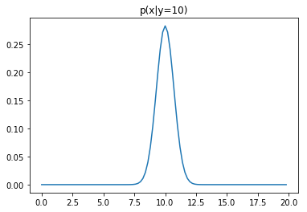

```python
tau2_inv = 1 / x_var + 1 / v_var
tau2 = 1 / tau2_inv

at2_denominator = x_var + v_var
at2_numerator1 = v_var * x_ave

xx = np.arange(0, 20, 0.2)

# y=10のとき
yi = 10
at2_numerator2 = x_var * yi
at2 = (at2_numerator1 + at2_numerator2) / at2_denominator
px_with_y = 1 / np.sqrt(2 * np.pi * tau2) * np.exp(-1 * (xx - at2)**2 / 2 * tau2 )

plt.plot(xx,px_with_y)
plt.title('p(x|y=10)')
plt.show()
```

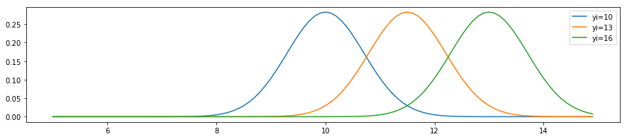

```python
xx = np.arange(5, 15, 0.1)

plt.figure(figsize=(15,3))
#
yi = 10
at2_numerator2 = x_var * yi
at2 = (at2_numerator1 + at2_numerator2) / at2_denominator
px_with_y = 1 / np.sqrt(2 * np.pi * tau2) * np.exp(-1 * (xx - at2)**2 / 2 * tau2 )
plt.plot(xx,px_with_y,label='yi='+str(yi))

#
yi = 13
at2_numerator2 = x_var * yi
at2 = (at2_numerator1 + at2_numerator2) / at2_denominator
px_with_y = 1 / np.sqrt(2 * np.pi * tau2) * np.exp(-1 * (xx - at2)**2 / 2 * tau2 )
plt.plot(xx,px_with_y,label='yi='+str(yi))

#
yi = 16
at2_numerator2 = x_var * yi
at2 = (at2_numerator1 + at2_numerator2) / at2_denominator
px_with_y = 1 / np.sqrt(2 * np.pi * tau2) * np.exp(-1 * (xx - at2)**2 / 2 * tau2 )
plt.plot(xx,px_with_y,label='yi='+str(yi))

#
plt.legend()
plt.show()
```

#### [数値例] 条件付き期待値

```python
# sample at a point
yi = y[0]
denominator = x_var + v_var
numerator = v_var*x_ave + x_var*yi
at2 = numerator / denominator
print(at2)
```

[output not shown]

```python
# loop
denominator = x_var + v_var
numerator1 = v_var * x_ave
yy = np.arange(0,20,0.5)
at2 = np.array([np.nan]*len(yy))
for i, yi in enumerate(yy):
    numerator2 = x_var * yi
    at2[i] = (numerator1 + numerator2) / denominator
```

```
横軸：yの観測値, 縦軸：E[x│y]
```

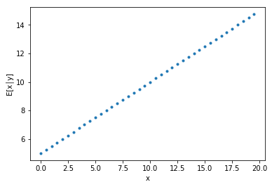

```python
#
print('横軸：yの観測値, 縦軸：E[x│y]')
plt.plot(yy, at2, '.')
plt.xlabel('x')
plt.ylabel('E[x│y]')
plt.show()
```

#### 乱数データへ適用

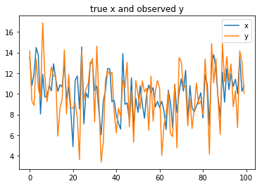

```python
# 再掲
plt.plot(x[:100],label='x')
plt.plot(y[:100],label='y')
plt.legend()
plt.title('true x and observed y')
plt.show()
```

```python
# expect from observed y
at2 = np.array([np.nan]*len(y))
for i, yi in enumerate(y):
    numerator2 = x_var * yi
    at2[i] = (numerator1 + numerator2) / denominator
```

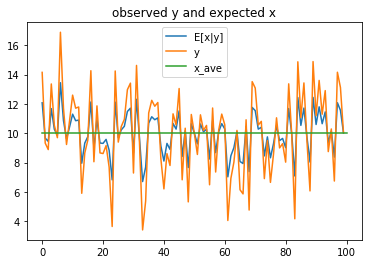

```python
plt.plot(at2[:100],label='E[x|y]')
plt.plot(y[:100],label='y')
plt.plot([0,100],[x_ave,x_ave],label='x_ave')
plt.legend()
plt.title('observed y and expected x')
plt.show()
```

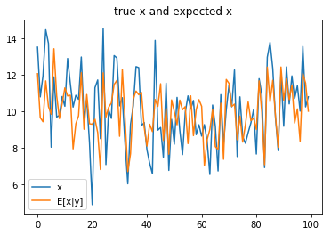

```python
plt.plot(x[:100],label='x')
plt.plot(at2[:100],label='E[x|y]')
plt.legend()
plt.title('true x and expected x')
plt.show()
```

## yの条件付き期待値とxの条件付き期待値

\begin{eqnarray} y = x + v, x～N(\overline{x},\sigma^2_a), v～N(0,\sigma^2_v) \end{eqnarray}

における \begin{eqnarray} && p(y \mid x) と p(x \mid y) \end{eqnarray}

### yの条件付き期待値

\begin{eqnarray} p(y \mid x) \end{eqnarray}

については、xが確定されたなら、 \begin{eqnarray} y = x + v \end{eqnarray} より、期待値がxで、分散がvの分散と等しい確率分布となることが分かる。よって \begin{eqnarray} p(y \mid x) = \frac {1} {\sqrt{ 2 \pi \sigma_v^2 }} \exp(- \frac { (y - x)^2 } {2 \sigma_v^2} ) \end{eqnarray}

### xの条件付き期待値

では \begin{eqnarray} p(x \mid y) \end{eqnarray} について同じ論法が使えるか？つまり、

> yが確定されたなら、 \begin{eqnarray} x = y - v \end{eqnarray} より、期待値がyで、分散がvの分散と等しい確率分布と考えられる?

結論から言えばNO。

1.  
まず、「x：原因」「y：結果」という違いがある。

2.  
x=x1が確定した後にyを求めるケースでは、  
原因：x1 + ランダムノイズ → 結果：y より  
「yの平均がx1であることは自明」である。  
一方、y=y1が確定した後にxを求めるケースでは、  
y1が生成された過程は未知であり、  
y=y1を満たすxとvの組み合わせは様々考えられる。  
よって、ただちに「xの平均がy1であることは自明」と言うことはできない。